# hvPlot 0.8.0 Release

release

hvplot

Release announcement for hvPlot 0.8.0

Author

Maxime Liquet

Published

August 25, 2022

[figure not shown]

**What is hvPlot?**

hvPlot is an open-source library that offers powerful high-level functionality for data exploration and visualization that doesn’t require you to learn a new API. For instance, if you have a Pandas or Xarray data pipeline already, you can turn it into a simple data-exploration app by starting the pipeline with `.interactive` and replacing method arguments with widgets. Or you can get powerful interactive and compositional [Bokeh](https://bokeh.org), [Plotly](https://plotly.com/python), or [Matplotlib](https://matplotlib.org) plots by simply replacing `.plot` with `.hvplot`. hvPlot makes all the analytical power of the [HoloViz](https://holoviz.org) ecosystem available, using the APIs you already know.

```python
import hvplot.pandas
from bokeh.sampledata import penguins

df = penguins.data
df.hvplot.scatter(x='bill_length_mm', y='bill_depth_mm', by='species')
```

[interactive chart not shown]

Check out the [hvPlot’s website](http://hvplot.pyviz.org/) to find out more!

[figure not shown]

**New release!**

We are very pleased to announce the **0.8.0** and **0.8.1** releases of hvPlot! The **0.8.0** release focused on adding a number of powerful features requested by our users, including:

- In addition to [Bokeh](http://bokeh.pydata.org/), hvPlot now **supports [Matplotlib](http://matplotlib.org/) and [Plotly](https://plotly.com/) plotting extensions**, so that the results of your exploratory analysis can be used alongside highly customized plots from your favorite library.
- `.interactive()` pipelines can now start with **functions as inputs**, not just from an existing data structure, so that you can make fully self-contained data apps from using hvPlot alone.
- The new hvPlot *Explorer* is a **UI component designed to easily explore data without having to write any code**; just drop it in your notebook or app and start exploring!

[@sophiamyang](https://twitter.com/sophiamyang) has created an awesome video that introduces you to the new features of hvPlot, check it out!

[video not shown]

While this blog post will focus on those three big features, hvPlot 0.8 includes a number of other enhancements and bug fixes that are of almost equal importance. For a detailed list of the changes, check out the release notes for hvPlot 0.8.0 and 0.8.1.

Many, many thanks to everyone who filed issues or contributed to this release. In particular we would like to thank @jbednar, @FabianHofmann, @jomey, @ablythed, @jlstevens, @MarcSkovMadsen, @Hoxbro, @michaelaye, @MridulS, @ppwadhwa, @maximlt, @philippjfr for contributing various fixes and improvements!

If you are using [conda](https://docs.conda.io/en/latest/), you can get the latest hvPlot with `conda install -c pyviz hvplot` , and using pip you can install it with `pip install hvplot`.

### New plotting extensions: [Matplotlib](http://matplotlib.org/) and [Plotly](https://plotly.com/python)

You may be surprised that despite its name, hvPlot is actually *not* a plotting library! Instead, it is a high-level interface that delegates the actual “plotting” work, i.e. how to display lines, points, etc. on a screen, to lower-level libraries. Until now, hvPlot was only able to delegate that work to Bokeh, one particular interactive plotting library. However, hvPlot happens to be built on top of HoloViews, which for years has had support for Matplotlib and Plotly as well. hvPlot now exposes those capabilities of HoloViews, which opens up new opportunities of hvPlot usage. For instance, you can now explore plots interactively using hvPlot, export them as Matplotlib figures, and then combine the output with other custom Matplotlib figures for a publication-ready workflow.

While Bokeh is still the default plotting backend of hvPlot, with the new `hvplot.extension()` utility you can now declare, usually at the start of a notebook, the plotting backend you would like to use.

```python
hvplot.extension('matplotlib')
```

Then just use hvPlot as you normally do, including optionally passing styling options that are compatible with the selected plotting backend.

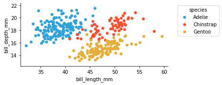

```python
scatter = df.hvplot.scatter(x='bill_length_mm', y='bill_depth_mm', by='species')
scatter.opts(fig_size=150)
```

Even if hvPlot allows you to customize your plots quite extensively, there are always situations when you need more! In those cases and in the spirit of the HoloViz mantra *shortcuts, not dead-ends*, you can get a handle on the actual plotting figure object with `hvplot.render()` and adapt it further to your liking.

```python
%matplotlib inline

import matplotlib.pyplot as plt

with plt.xkcd():
    fig = hvplot.render(scatter)
```

```python
fig
```

[figure not shown]

Head over to [hvPlot’s site](https://hvplot.holoviz.org/user_guide/Plotting_Extensions.html) to learn more about how to manage the extensions and have a look at the [Matplotlib](https://hvplot.holoviz.org/user_guide/Plotting_with_Matplotlib.html) and [Plotly](https://hvplot.holoviz.org/user_guide/Plotting_with_Plotly.html) pages of the site to get an overview of the kind of plots you have access to now.